# 12 - Generalized Estimation Equations and Special Distributions

### Model Diagnostics for GEE

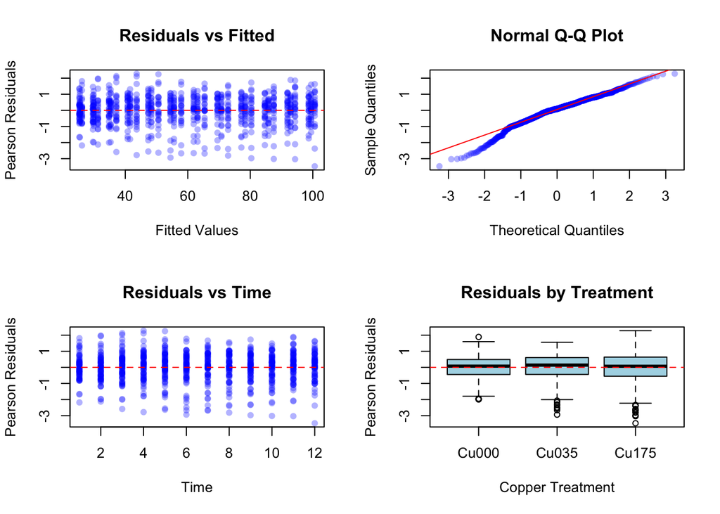

```r
# Residuals
residuals_gee <- residuals(gee_ar1, type="pearson")

# Diagnostic plots
par(mfrow=c(2,2))

# Residuals vs fitted
plot(fitted(gee_ar1), residuals_gee,
     xlab="Fitted Values", ylab="Pearson Residuals",
     main="Residuals vs Fitted", pch=16, col=rgb(0,0,1,0.3))
abline(h=0, col="red", lty=2)

# Q-Q plot
qqnorm(residuals_gee, main="Normal Q-Q Plot", pch=16, col=rgb(0,0,1,0.3))
qqline(residuals_gee, col="red")

# Residuals by time
plot(dietox$Time, residuals_gee,
     xlab="Time", ylab="Pearson Residuals",
     main="Residuals vs Time", pch=16, col=rgb(0,0,1,0.3))
abline(h=0, col="red", lty=2)

# Residuals by treatment
boxplot(residuals_gee ~ dietox$Cu,
        main="Residuals by Treatment",
        xlab="Copper Treatment", ylab="Pearson Residuals",
        col="lightblue")
abline(h=0, col="red", lty=2)
```

```r
par(mfrow=c(1,1))
```

## When to Use Each Approach

### Decision Tree for Count Data

```
##
## DECISION TREE FOR COUNT DATA ANALYSIS
## ======================================
##
## 1. Do you have COUNT data? (0, 1, 2, 3, ...)
##    YES → Continue
##    NO → Use appropriate GLM family (binomial, gamma, etc.)
##
## 2. Are observations INDEPENDENT?
##    NO (repeated measures, clustered) → Use GEE or Mixed Models
##    YES → Continue
##
## 3. Is there OVERDISPERSION? (Variance >> Mean)
##    NO → Try Poisson GLM
##    YES → Continue
##
## 4. Are there EXCESS ZEROS?
##    NO → Use Negative Binomial GLM
##    YES → Continue
##
## 5. Use ZERO-INFLATED models:
##    - If mild overdispersion → Zero-Inflated Poisson (ZIP)
##    - If strong overdispersion → Zero-Inflated Negative Binomial (ZINB)
##
## For correlated data with excess zeros:
## → Consider zero-inflated mixed models (not covered here)
```

### Summary Table

```
## [1] "METHOD SELECTION GUIDE:"
```

```
##              Method                                            Use.When
## 1       Poisson GLM      Count data, no overdispersion, independent obs
## 2 Negative Binomial         Count data, overdispersion, independent obs
## 3               ZIP      Excess zeros, mild overdispersion, independent
## 4              ZINB    Excess zeros, strong overdispersion, independent
## 5               GEE Correlated observations, population-level inference
## 6      Mixed Models    Correlated observations, subject-level inference
##                                     Assumption
## 1                  Independence, variance=mean
## 2                  Independence, variance>mean
## 3                  Independence, two processes
## 4 Independence, two processes + overdispersion
## 5              Specified correlation structure
## 6                     Random effects structure
```

## Final thoughts

Relaxing other assumptions allows us to properly analyze other kinds of data. On the one hand, **zero-inflated models** allow us to fit Poisson and negative binomial GLMs when we have an excess of zeros in our dataset, correcting the estimates and P-values by modeling two separate processes: one determining whether a zero occurs, and another determining the count when non-zero. On the other hand, **GEE** works in a similar way to GLMs but is able to operate with correlated observations (such as repeated measures or clustered data), which represent a major assumption violation in standard linear models.

### Key Takeaways:

**Zero-Inflated Models:** - Essential when you have more zeros than expected by standard distributions - Model two processes: zero-inflation and count generation - Use Vuong test to compare zero-inflated vs standard models - Choose between ZIP and ZINB based on overdispersion

**Generalized Estimation Equations:** - Appropriate for correlated/clustered data - Provide population-averaged (marginal) estimates - Require specification of correlation structure - More robust to misspecification than mixed models - Use QIC for model selection

**Best Practices:** 1. Always visualize your data first 2. Check for overdispersion using formal tests 3. Compare multiple models using AIC/QIC 4. Validate model fit with diagnostic plots 5. Choose correlation structure based on data structure 6. Report model selection process in your results

**When in doubt:** - Start with exploratory data analysis - Fit multiple candidate models - Use information criteria for comparison - Check model assumptions - Validate predictions against observed data

Licensing Creative Commons License

Licensed under a Creative Commons Attribution-ShareAlike 4.0 International License.  
2025 - Francisco E. Fontúrbel